# Exam 1

## Exam 1

#### Metainformation

1. | Tag | Value |
   | --- | --- |
   | `file` | Inferential_Statistics_uu-factor-analysis-021-nl_uu-factor-analysis-021-nl |
   | `name` | uu-factor-analysis-021-nl.Rmd |
   | `section` | Factor analysis |
   | `type` | schoice |
   | `solution` | TRUE, FALSE, FALSE, FALSE |
   | `Type` | Interpreting output |
   | `Program` | SPSS |
   | `Language` | Dutch |
   | `Level` | Statistical Literacy |

#### Question

   Marlies is bezig met het schrijven van de resultaten sectie van haar Bachelor thesis. Ze heeft onderzocht hoe milieubewust mensen zijn. Dit heeft ze gedaan aan de hand van een korte vragenlijst bestaande uit 7 stellingen waarvan mensen konden aangeven in hoeverre ze het met zo’n stelling eens of oneens waren op a.d.h.v. een 5-punts Likertschaal. Marlies heeft data verzameld onder 125 mannen en vrouwen in de regio Utrecht. Ze wil in dit deel van haar analyse bekijken of haar vragenlijst wel valide is. Om dit te doen voert ze een factoranalyse uit, waarvan delen van de resultaten hieronder staan.

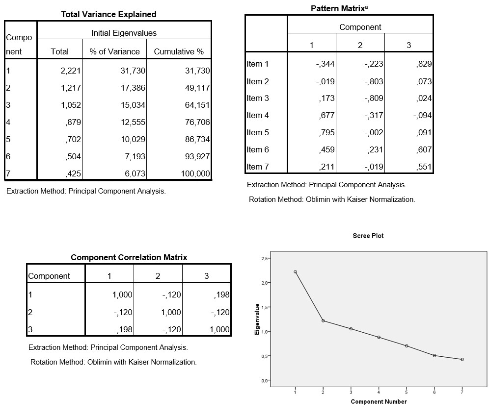

   Twee vrienden van Marlies lezen haar rapport en maken de volgende opmerkingen:

   Lars: “Om een definitieve beslissing te kunnen nemen over de uiteindelijke factoroplossing, heb ik nog wel de inhoud/betekenis van de items nodig.” Tim: “Om een definitieve beslissing te kunnen nemen over de uiteindelijke factoroplossing, moet ik nog wel iets weten over de verwachte dimensionaliteit van de vragenlijst.”

   Wie heeft er gelijk?
   1. **TRUE:** Lars en Tim hebben beide gelijk
   2. **FALSE:** Alleen Lars heeft gelijk
   3. **FALSE:** Alleen Tim heeft gelijk
   4. **FALSE:** Lars en Tim hebben geen van beide gelijk